# Practical Machine Learning Course Project

RAD

November 23, 2018

## Background

Using devices such as Jawbone Up, Nike FuelBand, and Fitbit it is now possible to collect a large amount of data about personal activity relatively inexpensively. These type of devices are part of the quantified self movement - a group of enthusiasts who take measurements about themselves regularly to improve their health, to find patterns in their behavior, or because they are tech geeks. One thing that people regularly do is quantify how much of a particular activity they do, but they rarely quantify how well they do it.

## Data

The training data for this project are available here:

https://d396qusza40orc.cloudfront.net/predmachlearn/pml-training.csv

The test data are available here:

https://d396qusza40orc.cloudfront.net/predmachlearn/pml-testing.csv

The data for this project come from this source: http://groupware.les.inf.puc-rio.br/har. If you use the document you create for this class for any purpose please cite them as they have been very generous in allowing their data to be used for this kind of assignment.

In this project, the goal is to use data to predict the manner in which they did the exercise. This is the * “classe” * variable in the training set which is a factor variable with 5 levels. The participants were asked to perform one set of 10 repetitions of the Unilateral Dumbbell Biceps Curl in 5 different fashions:

- exactly according to the specification (Class A)
- throwing the elbows to the front (Class B)
- lifting the dumbbell only halfway (Class C)
- lowering the dumbbell only halfway (Class D)
- throwing the hips to the front (Class E)

#### Cross-validation

The models will be fitted on the subset of Training data set, which consist of about 70% of the original Training dataset. These fitted models will then be tested on the remaining 30% of the Training dataset. After choosing the model with the highest accuracy, this model will then be tested on the original Testing dataset.

#### Out of Sample Error

The expected will correspond to the expected number of missclassified observations/total observations in the Test data set, which is the quantity: 1-accuracy found from the cross-validation data set.

## Results

#### Loading Packages

```r
library(knitr)
library(caret)
```

```r
library(rpart)
library(rpart.plot)
library(randomForest)
library(gbm)
set.seed(1995)
```

#### Reading and Cleaning Data

```r
dim(TrainingM)
```

```
## [1] 19622    53
```

```r
dim(TestingM)
```

```
## [1] 20 53
```

#### Partitioning Data

To perform cross-validation, the original Training dataset is divided into 2 subsets: the Training-subset (as mentionaed earlier, it comprises of 70% of the original Training dataset) and Testing-subset (remaining 30% of the Training dataset). Random sampling was done without replacement.

```r
library(caret)
set.seed(1995)
subTraining <- createDataPartition(TrainingM$classe, p=0.70, list=F)
subTraining_data <- TrainingM[subTraining, ]
subTesting_data <- TrainingM[-subTraining, ]
```

### Model Building

Three popular methods will be applied to model the regressions (in the original Train dataset) and the best one (with higher accuracy) will be used for the quiz predictions. The methods are: Decision Tree, Random Forests and Generalized Boosted Model.

#### Decision Tree

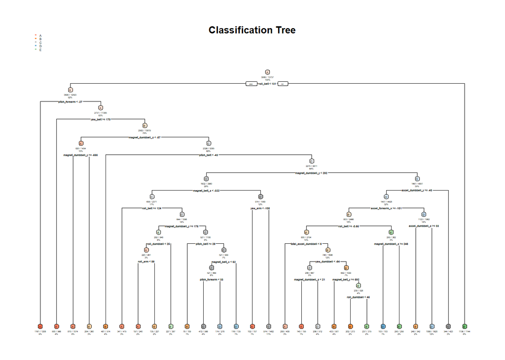

```r
Model1 <- rpart(classe ~ ., data=subTraining_data, method="class")

# Prediction
prediction1 <- predict(Model1, subTesting_data, type = "class")

# Plot of the Decision Tree
rpart.plot(Model1, main="Classification Tree", extra=102, under=TRUE, faclen=0)
```

```r
# Test results on the Testing-subset data set:
confusionMatrix(prediction1, subTesting_data$classe)
```

```
## Confusion Matrix and Statistics
##
##           Reference
## Prediction    A    B    C    D    E
##          A 1469  165   24   73   48
##          B   54  747   63   65   64
##          C   26  124  849  197  135
##          D  101   92   46  604   48
##          E   24   11   44   25  787
##
## Overall Statistics
##
##                Accuracy : 0.7572
##                  95% CI : (0.746, 0.7681)
##     No Information Rate : 0.2845
##     P-Value [Acc > NIR] : < 2.2e-16
##
##                   Kappa : 0.6924
##  Mcnemar's Test P-Value : < 2.2e-16
##
## Statistics by Class:
##
##                      Class: A Class: B Class: C Class: D Class: E
## Sensitivity            0.8775   0.6558   0.8275   0.6266   0.7274
## Specificity            0.9264   0.9482   0.9008   0.9417   0.9783
## Pos Pred Value         0.8257   0.7523   0.6379   0.6779   0.8833
## Neg Pred Value         0.9501   0.9199   0.9611   0.9279   0.9409
## Prevalence             0.2845   0.1935   0.1743   0.1638   0.1839
## Detection Rate         0.2496   0.1269   0.1443   0.1026   0.1337
## Detection Prevalence   0.3023   0.1687   0.2262   0.1514   0.1514
## Balanced Accuracy      0.9020   0.8020   0.8641   0.7841   0.8529
```

#### Random Forest

```r
Model2 <- randomForest(classe ~. , data=subTraining_data, method="class")

# Prediction
prediction2 <- predict(Model2,subTesting_data, type = "class")

# Test results on the Testing-subset dataset:
confusionMatrix(prediction2, data=subTesting_data$classe)
```

```
## Confusion Matrix and Statistics
##
##           Reference
## Prediction    A    B    C    D    E
##          A 1673    0    0    0    1
##          B    4 1135    0    0    0
##          C    0   11 1015    0    0
##          D    0    0    9  954    1
##          E    0    0    2    0 1080
##
## Overall Statistics
##
##                Accuracy : 0.9952
##                  95% CI : (0.9931, 0.9968)
##     No Information Rate : 0.285
##     P-Value [Acc > NIR] : < 2.2e-16
##
##                   Kappa : 0.994
##  Mcnemar's Test P-Value : NA
##
## Statistics by Class:
##
##                      Class: A Class: B Class: C Class: D Class: E
## Sensitivity            0.9976   0.9904   0.9893   1.0000   0.9982
## Specificity            0.9998   0.9992   0.9977   0.9980   0.9996
## Pos Pred Value         0.9994   0.9965   0.9893   0.9896   0.9982
## Neg Pred Value         0.9991   0.9977   0.9977   1.0000   0.9996
## Prevalence             0.2850   0.1947   0.1743   0.1621   0.1839
## Detection Rate         0.2843   0.1929   0.1725   0.1621   0.1835
## Detection Prevalence   0.2845   0.1935   0.1743   0.1638   0.1839
## Balanced Accuracy      0.9987   0.9948   0.9935   0.9990   0.9989
```

The accuracy of the model is 99.52% and the estimated out-of-sample error is 0.48%.

#### Generalized Boosted Model (GBM)

```r
GBM <- trainControl(method = "repeatedcv", number = 5,repeats = 1)
Model3  <- train(classe ~ ., data=subTraining_data,method = "gbm",trControl = GBM, verbose = FALSE)

# Prediction
prediction3 <- predict(Model3,newdata=subTesting_data)

# Test results on the Testing-subset dataset:
confusionMatrix(prediction3, data=subTesting_data$classe)
```

```
## Confusion Matrix and Statistics
##
##           Reference
## Prediction    A    B    C    D    E
##          A 1652   15    3    3    1
##          B   32 1081   21    5    0
##          C    0   36  977   12    1
##          D    0    2   31  924    7
##          E    3   13   14    7 1045
##
## Overall Statistics
##
##                Accuracy : 0.965
##                  95% CI : (0.96, 0.9695)
##     No Information Rate : 0.2867
##     P-Value [Acc > NIR] : < 2.2e-16
##
##                   Kappa : 0.9557
##  Mcnemar's Test P-Value : 1.714e-07
##
## Statistics by Class:
##
##                      Class: A Class: B Class: C Class: D Class: E
## Sensitivity            0.9793   0.9425   0.9340   0.9716   0.9915
## Specificity            0.9948   0.9878   0.9899   0.9919   0.9923
## Pos Pred Value         0.9869   0.9491   0.9522   0.9585   0.9658
## Neg Pred Value         0.9917   0.9861   0.9858   0.9945   0.9981
## Prevalence             0.2867   0.1949   0.1777   0.1616   0.1791
## Detection Rate         0.2807   0.1837   0.1660   0.1570   0.1776
## Detection Prevalence   0.2845   0.1935   0.1743   0.1638   0.1839
## Balanced Accuracy      0.9870   0.9651   0.9620   0.9818   0.9919
```

The accuracy of the model is 96.50% and the estimated out-of-sample error is 3.50%.

### The Final Model

Thus, the Random Forest model will be applied to predict the 20 observations in the original Testing dataset.

```r
predictTEST <- predict(Model2, newdata=TestingM)
predictTEST
```

```
##  1  2  3  4  5  6  7  8  9 10 11 12 13 14 15 16 17 18 19 20
##  B  A  B  A  A  E  D  B  A  A  B  C  B  A  E  E  A  B  B  B
## Levels: A B C D E
```